# ML Approaches

Petro Tolochko

2023-06-27

## Load the corpus

We use a labeled Movie Review Dataset to implement a simple supervised machine learning approach. The dataset contains 5,331 positive and 5,331 negative processed sentences from Rotten Tomatoes movie reviews. Our goal is to train a classifier that can predict whether a sentence is positive or negative.

This data was first used in Bo Pang and Lillian Lee, ``Seeing stars: Exploiting class relationships for sentiment categorization with respect to rating scales.’’, Proceedings of the ACL, 2005. Please find more information on the dataset here. https://huggingface.co/datasets/rotten_tomatoes

```r
library(tidyverse)
#reviews <- fread("rotten_tomatoes.csv", stringsAsFactors=F)


reviews <- read_csv("https://raw.githubusercontent.com/fabiennelind/text-as-data-in-R/main/data/rotten_tomatoes.csv")
```

## Inspect the data

```r
colnames(reviews)
```

```
## [1] "value"    "polarity"
```

```r
names(reviews)[names(reviews) == 'value'] <- 'text' #give the column with the text a useful name
class(reviews$text)
```

```
## [1] "character"
```

```r
table(reviews$polarity) #check the distribution of the outcome variable
```

```
##
## negative positive
##     5331     5331
```

```r
class(reviews$polarity)
```

```
## [1] "character"
```

We now work with the R package quanteda. Please check out the following tutorials. https://quanteda.io/articles/quickstart.html https://content-analysis-with-r.com/5-machine_learning.html https://tutorials.quanteda.io/basic-operations/corpus/corpus/

Create a corpus and look at a summary.

```r
library(quanteda)
reviews_corpus <- corpus(reviews)
summary(reviews_corpus, 5)
```

```
## Corpus consisting of 10662 documents, showing 5 documents:
##
##   Text Types Tokens Sentences polarity
##  text1    31     34         1 positive
##  text2    31     41         1 positive
##  text3     4      4         1 positive
##  text4    18     21         1 positive
##  text5    21     21         1 positive
```

```r
# create docvar with ID
reviews_corpus$id_numeric <- 1:ndoc(reviews_corpus)
summary(reviews_corpus, 5)
```

```
## Corpus consisting of 10662 documents, showing 5 documents:
##
##   Text Types Tokens Sentences polarity id_numeric
##  text1    31     34         1 positive          1
##  text2    31     41         1 positive          2
##  text3     4      4         1 positive          3
##  text4    18     21         1 positive          4
##  text5    21     21         1 positive          5
```

Create a vector which includes the ids for the training part (here 80%) and for the test data (here 20%). We randomly select the 80%. The remaining reviews are assigned as test cases. Once we have the DFM, we split it into training and test set. We’ll go with 80% training and 20% set. Note the use of a random seed to make sure our results are replicable.

```r
set.seed(666)
id_train <- sample(1:nrow(reviews), floor(.80 * nrow(reviews)))
id_test <- (1:nrow(reviews))[1:nrow(reviews) %in% id_train == FALSE]
```

```r
# tokenize texts and represent as dfm
toks_reviews <- tokens(reviews_corpus, remove_punct = TRUE, remove_number = TRUE) %>%
               tokens_remove(pattern = stopwords("en")) %>%
               tokens_wordstem()
dfm_reviews <- dfm(toks_reviews)
dfm_reviews
```

```
## Document-feature matrix of: 10,662 documents, 14,038 features (99.93% sparse) and 2 docvars.
##        features
## docs    rock destin 21st centuri new conan go make splash even
##   text1    1      1    1       1   1     1  1    1      1    1
##   text2    0      0    0       0   0     0  0    0      0    0
##   text3    0      0    0       0   0     0  0    0      0    0
##   text4    0      0    0       0   0     0  1    0      0    0
##   text5    0      0    0       0   0     0  0    0      0    0
##   text6    0      0    0       0   0     0  0    0      0    1
## [ reached max_ndoc ... 10,656 more documents, reached max_nfeat ... 14,028 more features ]
```

```r
dfm_reviews_trim <- dfm_trim(dfm_reviews, min_docfreq = 2, verbose=TRUE)
```

```
## Removing features occurring:
```

```
##   - in fewer than 2 documents: 6,489
```

```
##   Total features removed: 6,489 (46.2%).
```

```r
dfm_reviews_trim
```

```
## Document-feature matrix of: 10,662 documents, 7,549 features (99.87% sparse) and 2 docvars.
##        features
## docs    rock destin 21st centuri new conan go make splash even
##   text1    1      1    1       1   1     1  1    1      1    1
##   text2    0      0    0       0   0     0  0    0      0    0
##   text3    0      0    0       0   0     0  0    0      0    0
##   text4    0      0    0       0   0     0  1    0      0    0
##   text5    0      0    0       0   0     0  0    0      0    0
##   text6    0      0    0       0   0     0  0    0      0    1
## [ reached max_ndoc ... 10,656 more documents, reached max_nfeat ... 7,539 more features ]
```

Split the dfm in two parts, a training and a test part.

```r
# get training set
dfm_train <- dfm_subset(dfm_reviews_trim, id_numeric %in% id_train)

# get test set (documents not in id_train)
dfm_test <- dfm_subset(dfm_reviews_trim, !id_numeric %in% id_train)
```

#Training

Fit a Naïve Bayes Classifier on the training dfm and save the learned model in the object ‘model.NB’. The Naïve Bayes Classifier is part of the library quanteda.textmodels.

```r
library(quanteda.textmodels)
model_NB <- textmodel_nb(dfm_train, dfm_train$polarity, prior = "docfreq")
```

Fit a Linear SVM classifier on the training dfm and save the learned model in the object ‘model.svm’.

```r
library(quanteda.textmodels)
model_svm <- textmodel_svm(dfm_train, dfm_train$polarity, prior = "docfreq")
```

#Predict for the test set

```r
pred_nb <- predict(model_NB, dfm_test, force = TRUE) # force = True will force your test data to give identical features (and ordering of features) to the training set
```

```r
summary(pred_nb)
```

```
## negative positive
##     1053     1080
```

```r
pred_svm <- predict(model_svm, dfm_test, force = TRUE) # force = True will force your test data to give identical features (and ordering of features) to the training set
```

Add the labels predicted by the model to the initial dataframe. Name the new column polarity_ml.

```r
colnames(reviews)
```

```
## [1] "text"     "polarity"
```

```r
reviews$id <- 1:nrow(reviews)
reviews_test <- subset(reviews, id %in% id_test)
reviews_test$polarity_ml <- pred_nb
colnames(reviews_test)
```

```
## [1] "text"        "polarity"    "id"          "polarity_ml"
```

## Compare automated with manual classifications

We compare the automated classification (in column `polarity_ml`) with the manual classifications (in column `polarity`) we use three metrics: Recall, Precision, and F1. The metrics inform us about the quality of the classifier. All three metrics range from 0 to 1.

To calculate the three metrics, we need first to create three new columns via some recoding.

The column `Positive_andRetrieved` includes a 1 if the manual coder and the classifier coded positive. = True positive The column `Positive_notRetrieved` includes a 1 if the manual coder coded positive but the classifier coded negative. = False negative The column `notPositive_butRetrieved` includes a 1 if the manual coder coded negative but the classifier coded 1. = False positive

```r
reviews_test$Positive_andRetrieved[reviews_test$polarity == "positive" & reviews_test$polarity_ml== "positive" ] <- 1
reviews_test$Positive_notRetrieved[reviews_test$polarity == "positive" & reviews_test$polarity_ml == "negative" ] <- 1
reviews_test$notPositive_butRetrieved[reviews_test$polarity == "negative" & reviews_test$polarity_ml == "positive" ] <- 1
```

### Recall

By inspecting recall we can say how many positive reviews are retrieved by the classifier. A recall of 1.0 means that our classifier retrieved all positive reviews. A recall of 0.8 means that our classifier retrieved 80% of all positive reviews.

To obtain recall, we calculate:

```r
recall_pos <- (sum(reviews_test$Positive_andRetrieved, na.rm=TRUE))/(sum(reviews_test$Positive_notRetrieved, na.rm=TRUE) + (sum(reviews_test$Positive_andRetrieved, na.rm=TRUE)))
recall_pos
```

```
## [1] 0.78907
```

### Precision

By inspecting precision we can say how many retrieved reviews are truely positive. A precision of 1,0 means that all reviews retrieved by the classifier are truely positive. A precision of 0.8 means that 80% of the reviews that our classifier retrieved are truely positive reviews.

To obtain precision, we calculate:

```r
precision_pos <- (sum(reviews_test$Positive_andRetrieved, na.rm=TRUE))/(sum(reviews_test$notPositive_butRetrieved, na.rm=TRUE) + (sum(reviews_test$Positive_andRetrieved, na.rm=TRUE)))
precision_pos #
```

```
## [1] 0.762037
```

### F1

F1 is the harmonic mean between recall and precision.

To obtain F1, we calculate:

```r
F1 <- (2 * precision_pos * recall_pos)/(precision_pos + recall_pos)
F1
```

```
## [1] 0.7753179
```

# Preparation

### Required Packages

We first need to install the packages required for further analysis.

```r
# install.packages("tm")
# install.packages("tidyverse")
# install.packages("ggthemes")
# install.packages("ggrepel")
# install.packages("cowplot")
# install.packages("quanteda")
# install.packages("quanteda.textmodels")



# install.packages(quanteda.textplots)
# install.packages("gtools")
# install.packages("sotu")
# install.packages("stm")
# install.packages(c("Rtsne", "rsvd", "geometry", "purrr"))
```

Note: you only need to install the packages once.

We then need load the packages in our environment:

```r
library(tm)
library(tidyverse)
library(ggthemes)
library(ggrepel)
library(quanteda)
library(quanteda.textmodels)
library(gtools)
library(sotu)
library(stm)
library(purrr)
library(quanteda.textplots)
```

# K-Means Clustering

## Let’s first generate some data!

We will use multinomial models to generate data. Generate texts about bananas and chocolate.

```r
set.seed(123)

# Priors
theta_1 <- rdirichlet(1, c(1, 6))
theta_2 <- rdirichlet(1, c(6, 1))

vocabulary <- c("banana", "chocolate")

w <- 200 # numbers of words to generate
n <- 100

generate_text <- function(n, theta) {
  sample(vocabulary, rbinom(1, w, .5), replace = TRUE, prob = theta) %>%
  paste(collapse = " ")
}



text_type_1 <- replicate(n, generate_text(w, rdirichlet(1, c(2, 8))))
text_type_2 <- replicate(n, generate_text(w, rdirichlet(1, c(8, 2))))




all_texts <- c(text_type_1, text_type_2)

dtm <- DocumentTermMatrix(all_texts) %>% as.matrix()
dtm
```

```
##      Terms
## Docs  banana chocolate
##   1       35        81
##   2       10        96
##   3       22        67
##   4        8        89
##   5       27        71
##   6        0       106
##   7        3        90
##   8       25        61
##   9       10        93
##   10       3       100
##   11      18        72
##   12      24        74
##   13       7        94
```

[output cut: 187 more lines]

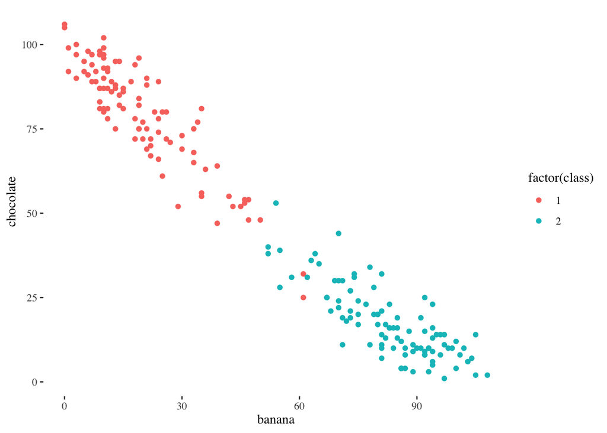

```r
dtm %>% as_tibble() %>%
  mutate(class = c(rep(1, n), rep(2, n))) %>%
  ggplot() +
  geom_point(aes(banana, chocolate, color = factor(class))) +
  theme_tufte()
```

```r
#
#
#
# # Modesl
# texts_1 <- rmultinom(n, 2, theta_1) %>%
#   t() %>%
#   as_tibble() %>%
#   mutate(banan = V1,
#          chocolate = V2,
#          type = 1) %>%
#   select(-V1, -V2)
#
# texts_2 <- rmultinom(n, 2, theta_2) %>%
#   t() %>%
#   as_tibble() %>%
#     mutate(banan = V1,
#          chocolate = V2,
#          type = 2) %>%
#   select(-V1, -V2)
```

# Now let’s try clustering them!

It’s very easy. We’re using `kmeans` function from base `r`.

```r
clustering.kmeans <- kmeans(dtm, 2)
clustering.kmeans
```

```
## K-means clustering with 2 clusters of sizes 98, 102
##
## Cluster means:
##     banana chocolate
## 1 18.93878  80.51020
## 2 82.25490  17.59804
##
## Clustering vector:
##   1   2   3   4   5   6   7   8   9  10  11  12  13  14  15  16  17  18  19  20
##   1   1   1   1   1   1   1   1   1   1   1   1   1   1   1   1   1   1   1   1
##  21  22  23  24  25  26  27  28  29  30  31  32  33  34  35  36  37  38  39  40
##   1   1   1   1   1   1   1   1   1   1   1   1   2   1   1   1   1   1   1   1
##  41  42  43  44  45  46  47  48  49  50  51  52  53  54  55  56  57  58  59  60
##   1   1   1   1   1   1   1   1   1   1   1   1   1   1   2   1   1   1   1   1
##  61  62  63  64  65  66  67  68  69  70  71  72  73  74  75  76  77  78  79  80
##   1   1   1   1   1   1   1   1   1   1   1   1   1   1   1   1   1   1   1   1
##  81  82  83  84  85  86  87  88  89  90  91  92  93  94  95  96  97  98  99 100
##   1   1   2   1   1   1   1   1   1   1   1   1   1   1   1   1   1   1   1   1
## 101 102 103 104 105 106 107 108 109 110 111 112 113 114 115 116 117 118 119 120
##   2   2   2   2   2   2   2   2   2   2   2   2   2   1   2   2   2   2   2   2
## 121 122 123 124 125 126 127 128 129 130 131 132 133 134 135 136 137 138 139 140
##   2   2   2   2   2   2   2   2   2   2   2   2   2   2   2   2   2   2   2   2
## 141 142 143 144 145 146 147 148 149 150 151 152 153 154 155 156 157 158 159 160
##   2   2   2   2   2   2   2   2   2   2   2   2   2   2   2   2   2   2   2   2
## 161 162 163 164 165 166 167 168 169 170 171 172 173 174 175 176 177 178 179 180
##   2   2   2   2   2   2   2   2   2   2   2   2   2   2   2   2   2   2   2   2
## 181 182 183 184 185 186 187 188 189 190 191 192 193 194 195 196 197 198 199 200
##   2   2   2   2   2   2   2   2   2   2   2   2   2   2   2   2   2   2   2   2
##
## Within cluster sum of squares by cluster:
## [1] 35612.12 29089.89
##  (between_SS / total_SS =  86.0 %)
##
## Available components:
##
## [1] "cluster"      "centers"      "totss"        "withinss"     "tot.withinss"
## [6] "betweenss"    "size"         "iter"         "ifault"
```

Let’s look at the cluster assignment:

```r
cluster <- clustering.kmeans$cluster
centroids <- clustering.kmeans$centers

cluster
```

```
##   1   2   3   4   5   6   7   8   9  10  11  12  13  14  15  16  17  18  19  20
##   1   1   1   1   1   1   1   1   1   1   1   1   1   1   1   1   1   1   1   1
##  21  22  23  24  25  26  27  28  29  30  31  32  33  34  35  36  37  38  39  40
##   1   1   1   1   1   1   1   1   1   1   1   1   2   1   1   1   1   1   1   1
##  41  42  43  44  45  46  47  48  49  50  51  52  53  54  55  56  57  58  59  60
##   1   1   1   1   1   1   1   1   1   1   1   1   1   1   2   1   1   1   1   1
##  61  62  63  64  65  66  67  68  69  70  71  72  73  74  75  76  77  78  79  80
##   1   1   1   1   1   1   1   1   1   1   1   1   1   1   1   1   1   1   1   1
##  81  82  83  84  85  86  87  88  89  90  91  92  93  94  95  96  97  98  99 100
##   1   1   2   1   1   1   1   1   1   1   1   1   1   1   1   1   1   1   1   1
## 101 102 103 104 105 106 107 108 109 110 111 112 113 114 115 116 117 118 119 120
##   2   2   2   2   2   2   2   2   2   2   2   2   2   1   2   2   2   2   2   2
## 121 122 123 124 125 126 127 128 129 130 131 132 133 134 135 136 137 138 139 140
##   2   2   2   2   2   2   2   2   2   2   2   2   2   2   2   2   2   2   2   2
## 141 142 143 144 145 146 147 148 149 150 151 152 153 154 155 156 157 158 159 160
##   2   2   2   2   2   2   2   2   2   2   2   2   2   2   2   2   2   2   2   2
## 161 162 163 164 165 166 167 168 169 170 171 172 173 174 175 176 177 178 179 180
##   2   2   2   2   2   2   2   2   2   2   2   2   2   2   2   2   2   2   2   2
## 181 182 183 184 185 186 187 188 189 190 191 192 193 194 195 196 197 198 199 200
##   2   2   2   2   2   2   2   2   2   2   2   2   2   2   2   2   2   2   2   2
```

```r
centroids
```

```
##     banana chocolate
## 1 18.93878  80.51020
## 2 82.25490  17.59804
```

And assign to our data:

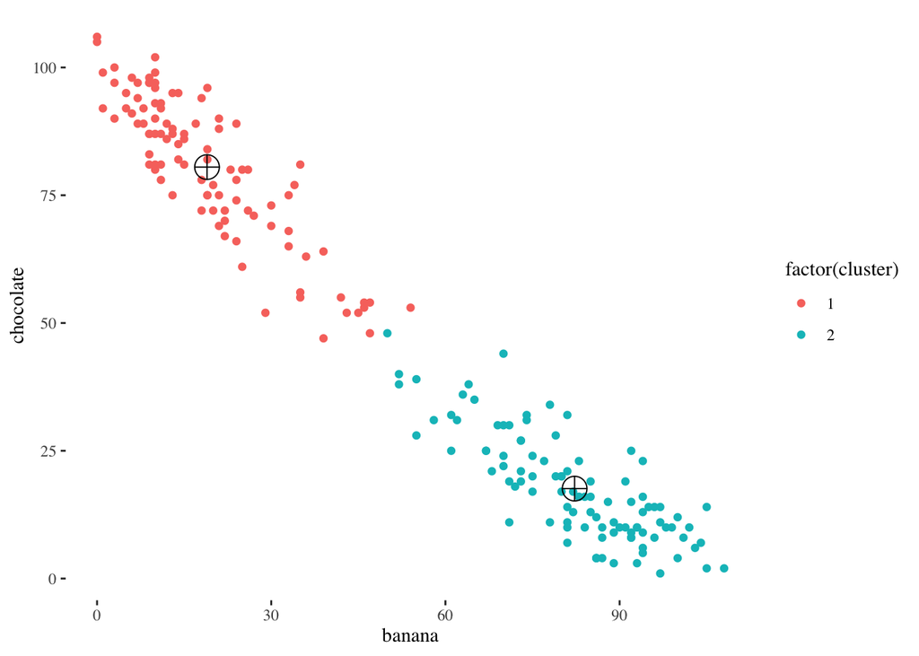

```r
dtm %>% as_tibble() %>%
  mutate(cluster = cluster) %>%
  ggplot() +
  geom_point(aes(banana, chocolate, color = factor(cluster))) +
  geom_point(aes(banana, chocolate), data = as_tibble(centroids),
             size = 6, shape = 10) +
  theme_tufte()
```

Ok, let’s add some more data!

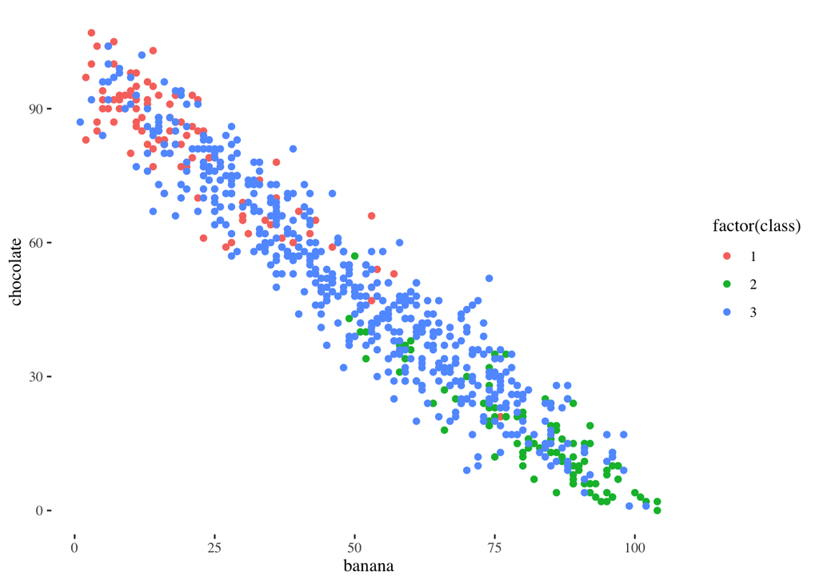

```r
text_type_1 <- replicate(n, generate_text(w, rdirichlet(1, c(2, 8))))
text_type_2 <- replicate(n, generate_text(w, rdirichlet(1, c(8, 2))))
text_type_3 <- replicate(500, generate_text(w + 100, rdirichlet(1, c(2, 2))))




all_texts <- c(text_type_1, text_type_2, text_type_3)
dtm <- DocumentTermMatrix(all_texts) %>% as.matrix()

dtm %>% as_tibble() %>%
  mutate(class = c(rep(1, n), rep(2, n), rep(3, 500))) %>%
  ggplot() +
  geom_point(aes(banana, chocolate, color = factor(class))) +
  theme_tufte()
```

A bit more interesting!

```r
clustering.kmeans <- kmeans(dtm, 3)
clustering.kmeans
```

```
## K-means clustering with 3 clusters of sizes 225, 223, 252
##
## Cluster means:
##     banana chocolate
## 1 20.40000  80.92444
## 2 79.98655  20.10762
## 3 50.57540  48.60317
##
## Clustering vector:
##   1   2   3   4   5   6   7   8   9  10  11  12  13  14  15  16  17  18  19  20
##   1   3   1   1   1   1   1   1   3   1   3   1   3   3   1   1   1   1   1   1
##  21  22  23  24  25  26  27  28  29  30  31  32  33  34  35  36  37  38  39  40
##   1   1   3   1   1   2   3   1   1   1   1   1   1   1   1   1   1   3   1   1
##  41  42  43  44  45  46  47  48  49  50  51  52  53  54  55  56  57  58  59  60
##   1   1   1   3   1   1   1   3   1   1   1   1   1   3   1   3   1   1   1   1
```

[output cut: 73 more lines]

```r
cluster <- clustering.kmeans$cluster
centroids <- clustering.kmeans$centers
```

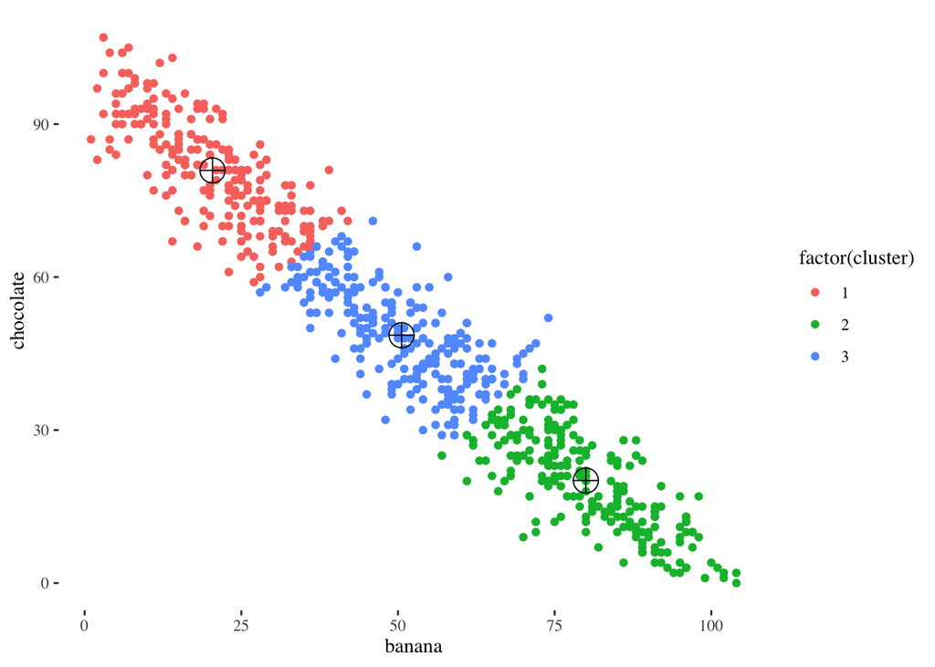

```r
dtm %>% as_tibble() %>%
  mutate(cluster = cluster) %>%
  ggplot() +
  geom_point(aes(banana, chocolate, color = factor(cluster))) +
  geom_point(aes(banana, chocolate), data = as_tibble(centroids),
             size = 6, shape = 10) +
  theme_tufte()
```

# Task: try different number of clusters and complare the clustering solution

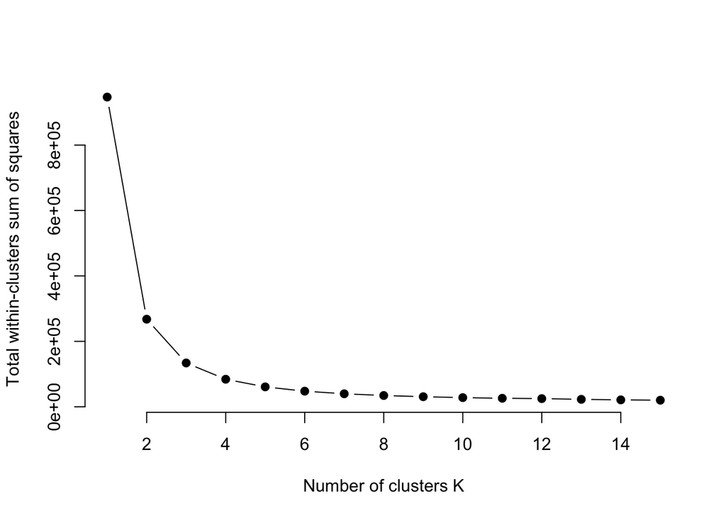

```r
set.seed(123)

# function to compute total within-cluster sum of square
wss <- function(k) {
  kmeans(dtm, k, nstart = 10)$tot.withinss
}

# Compute and plot wss for k = 1 to k = 3
k.values <- 1:15

# extract wss for 2-15 clusters
wss_values <- map_dbl(k.values, wss)

plot(k.values, wss_values,
       type="b", pch = 19, frame = FALSE,
       xlab="Number of clusters K",
       ylab="Total within-clusters sum of squares")
```

# Text scaling

From https://burtmonroe.github.io/TextAsDataCourse/Tutorials/IntroductionToWordfish.nb.html

```r
# Irish budget speeches from 2010


toks_irish <- tokens(data_corpus_irishbudget2010, remove_punct = TRUE)
dfmat_irish <- dfm(toks_irish)
tmod_wf <- textmodel_wordfish(dfmat_irish, dir = c(6, 5))
summary(tmod_wf)
```

```
##
## Call:
## textmodel_wordfish.dfm(x = dfmat_irish, dir = c(6, 5))
##
## Estimated Document Positions:
##                              theta      se
## Lenihan, Brian (FF)        1.79395 0.02007
## Bruton, Richard (FG)      -0.62137 0.02824
## Burton, Joan (LAB)        -1.13501 0.01568
## Morgan, Arthur (SF)       -0.07840 0.02896
## Cowen, Brian (FF)          1.77839 0.02330
## Kenny, Enda (FG)          -0.75343 0.02635
## ODonnell, Kieran (FG)     -0.47615 0.04309
## Gilmore, Eamon (LAB)      -0.58474 0.02992
## Higgins, Michael (LAB)    -1.00390 0.03964
## Quinn, Ruairi (LAB)       -0.92648 0.04183
## Gormley, John (Green)      1.18354 0.07224
## Ryan, Eamon (Green)        0.14816 0.06322
## Cuffe, Ciaran (Green)      0.71537 0.07291
## OCaolain, Caoimhghin (SF) -0.03993 0.03877
##
## Estimated Feature Scores:
##         when      i presented    the supplementary  budget     to   this  house
## beta -0.1593 0.3179    0.3604 0.1934         1.077 0.03546 0.3078 0.2474 0.1399
## psi   1.6241 2.7239   -1.7958 5.3308        -1.134 2.70992 4.5190 3.4603 1.0396
##        last   april    said     we   could   work    our    way through  period
## beta 0.2420 -0.1563 -0.8339 0.4158 -0.6138 0.5223 0.6894 0.2751  0.6116  0.4986
## psi  0.9853 -0.5725 -0.4515 3.5124  1.0857 1.1151 2.5277 1.4190  1.1604 -0.1779
##          of severe economic distress   today    can  report   that
## beta 0.2778  1.229   0.4238    1.799 0.09153 0.3041  0.6199 0.0152
## psi  4.4656 -2.013   1.5714   -4.456 0.83874 1.5644 -0.2467 3.8379
##      notwithstanding difficulties   past
## beta           1.799        1.175 0.4747
## psi           -4.456       -1.357 0.9321
```

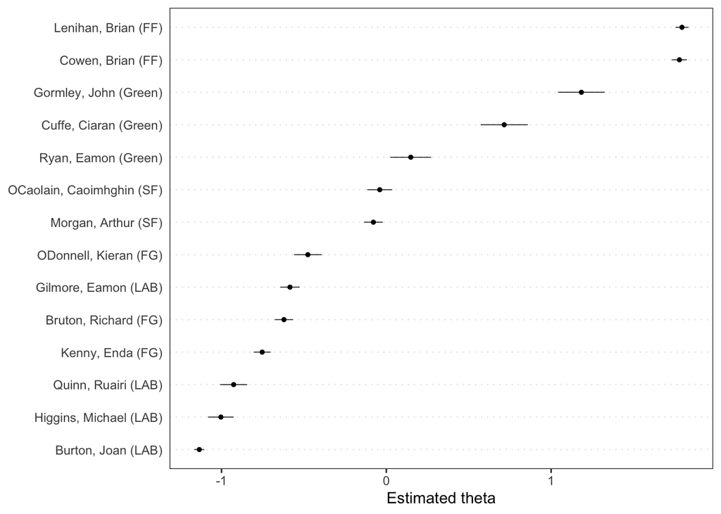

```r
textplot_scale1d(tmod_wf)
```

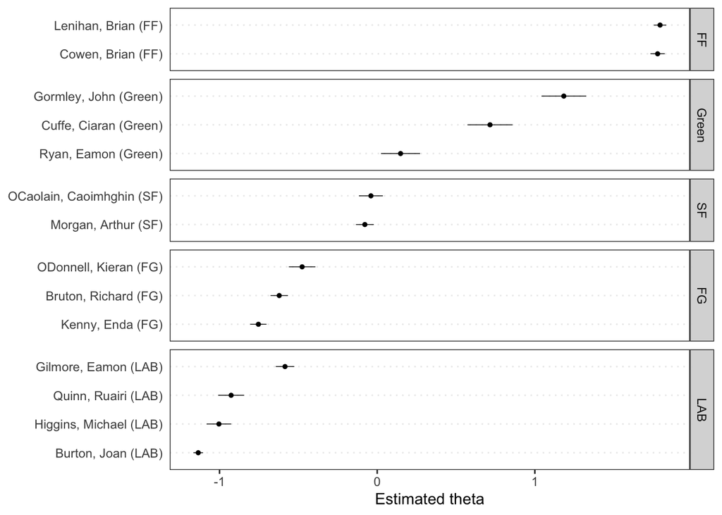

```r
textplot_scale1d(tmod_wf, groups = dfmat_irish$party)
```

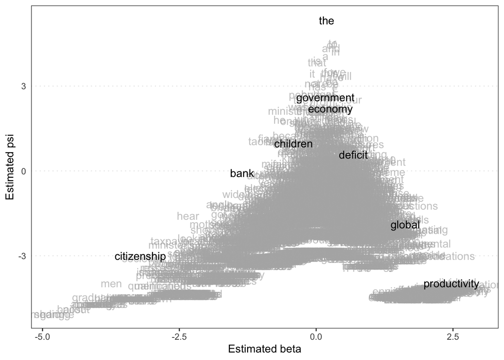

```r
textplot_scale1d(tmod_wf, margin = "features",
                 highlighted = c("government", "global", "children",
                                 "bank", "economy", "the", "citizenship",
                                 "productivity", "deficit"))
```

Topic models can also do unidimensional scaling!

```r
dfmat_irish_stm <- quanteda::convert(dfmat_irish, to = "stm")
names(dfmat_irish_stm)
```

```
## [1] "documents" "vocab"     "meta"
```

```r
irish_stmfit <- stm(documents = dfmat_irish_stm$documents,
                     vocab = dfmat_irish_stm$vocab,
                     K = 2,
                     max.em.its = 75,
                     data = dfmat_irish_stm$meta,
                     init.type = "Spectral"
)
```

[output not shown]

[output cut: 12 more lines]

[output not shown]

```r
compare.df <- cbind(name=rownames(docvars(dfmat_irish)),wordfish = tmod_wf$theta, stm = irish_stmfit$theta[,2])
compare.df
```

```
##       name wordfish              stm
##  [1,] "1"  "1.7939525940103"     "0.999856413780379"
##  [2,] "2"  "-0.62136840790286"   "0.774604594044597"
##  [3,] "3"  "-1.13501126312838"   "0.000209926082396561"
##  [4,] "4"  "-0.0784035441263312" "0.000345705990393679"
##  [5,] "5"  "1.77839279585767"    "0.9998131172257"
##  [6,] "6"  "-0.753426375315632"  "0.000319302879177373"
##  [7,] "7"  "-0.47615363594704"   "0.000792269895033178"
##  [8,] "8"  "-0.58474310795652"   "0.000582960655753373"
##  [9,] "9"  "-1.00389867131574"   "0.470666141616242"
## [10,] "10" "-0.926483567016404"  "0.489043184909732"
## [11,] "11" "1.18354437979617"    "0.997922283827153"
## [12,] "12" "0.14815927345194"    "0.996624540457028"
## [13,] "13" "0.715368140729653"   "0.998058889709461"
## [14,] "14" "-0.0399286111368352" "0.000426769783914437"
```